# Appus - Questão 1

Lucas Murtinho

April 19, 2016

# Preparação

## Semente aleatória

Definição de semente aleatória para reproducibilidade dos resultados.

```r
set.seed(1)
```

## Pasta

Pasta com os dados.

```r
rm(list=ls())
pasta = 'E:/Drive/appus/'
```

## Carregar módulos

Módulos utilizados na análise.

```r
library(Boruta)
library(caret) # tratamento de dados e seleção de hiperparâmetros
```

```r
library(ggplot2) # gráficos
library(lubridate) # datas
library(ROCR) # análise de performance
```

## Opções de gráfico

Layout dos gráficos.

```r
theme_set(theme_bw())
```

## Ler dados

Leitura dos dados, com as categorias definidas no documento sobre os dados e colunas renomeadas.

```r
dados = read.csv2(paste0(pasta, "questao1.csv"),
                  colClasses=c(rep("factor", 2), "character", "factor",
                               "character", rep("factor", 2), "character",
                               rep("factor", 2), "factor", rep("numeric", 3)),
                  fileEncoding = 'ISO-8859-1')

names(dados) = c("desligamento",
                 "ex_trainee",
                 "data_nascimento",
                 "sexo",
                 "data_admissao",
                 "cargo",
                 "area",
                 "salario",
                 "pos_critica",
                 "gestor",
                 "aval",
                 "dist",
                 "tempo",
                 "turnover")
```

# Limpeza de dados

## Primeira vista

```r
str(dados)
```

```
## 'data.frame':    2500 obs. of  15 variables:
##  $ desligamento   : Factor w/ 2 levels "0","1": 1 1 1 1 2 1 1 1 1 1 ...
##  $ ex_trainee     : Factor w/ 2 levels "0","1": 1 1 1 1 1 1 1 1 1 1 ...
##  $ data_nascimento: chr  "16/10/1963" "27/04/1963" "29/01/1960" "14/07/1941" ...
##  $ sexo           : Factor w/ 2 levels "F","M": 2 2 2 2 2 2 2 2 2 2 ...
##  $ data_admissao  : chr  "1/27/03" "10/05/1992" "01/03/1989" "06/05/1991" ...
##  $ cargo          : Factor w/ 885 levels "1","10","100",..: 1 112 223 334 444 555 666 777 875 2 ...
##  $ area           : Factor w/ 8 levels "Administrativo",..: 7 1 1 7 3 7 7 3 7 3 ...
##  $ salario        : chr  "R$ 5.080,00" "R$ 12.498,33" "R$ 9.966,67" "R$ 3.795,00" ...
##  $ pos_critica    : Factor w/ 2 levels "0","1": 1 1 1 1 2 1 1 2 1 2 ...
##  $ gestor         : Factor w/ 820 levels "1","10","100",..: 1 112 223 334 445 334 556 445 667 778 ...
##  $ aval           : Factor w/ 4 levels "BOM","EXCELENTE",..: 1 1 1 4 4 1 4 1 1 1 ...
##  $ dist           : num  25 29 10 25 14 13 10 19 24 2 ...
##  $ tempo          : num  17 20 6 17 9 9 6 13 16 1 ...
##  $ turnover       : num  0.03 0.17 0.23 0.11 0.02 0.16 0.04 0.13 0.09 0.12 ...
##  $ NA             : Factor w/ 1 level "": 1 1 1 1 1 1 1 1 1 1 ...
```

Remoção da coluna extra no fim da tabela de dados:

```r
dados = dados[,-ncol(dados)]
```

## Data de nascimento

As datas de nascimento precisam ser transformadas de string para formatos de data, mas há dois formatos diferentes. Vou criar dois vetores e transformar os dados duas vezes.

```r
nasc_1 = as.Date(dados$data_nascimento, "%d/%m/%Y")
nasc_2 = as.Date(dados$data_nascimento, "%m/%d/%y")

dados$data_nascimento = as.Date(nasc_1)

dados$data_nascimento[is.na(dados$data_nascimento)] =
  as.Date(nasc_2[is.na(dados$data_nascimento)])
```

Resultado da transformação:

```r
summary(dados$data_nascimento)
```

```
##         Min.      1st Qu.       Median         Mean      3rd Qu.
## "1900-10-25" "1976-02-22" "1983-02-20" "1984-04-25" "1990-02-13"
##         Max.
## "2068-12-15"
```

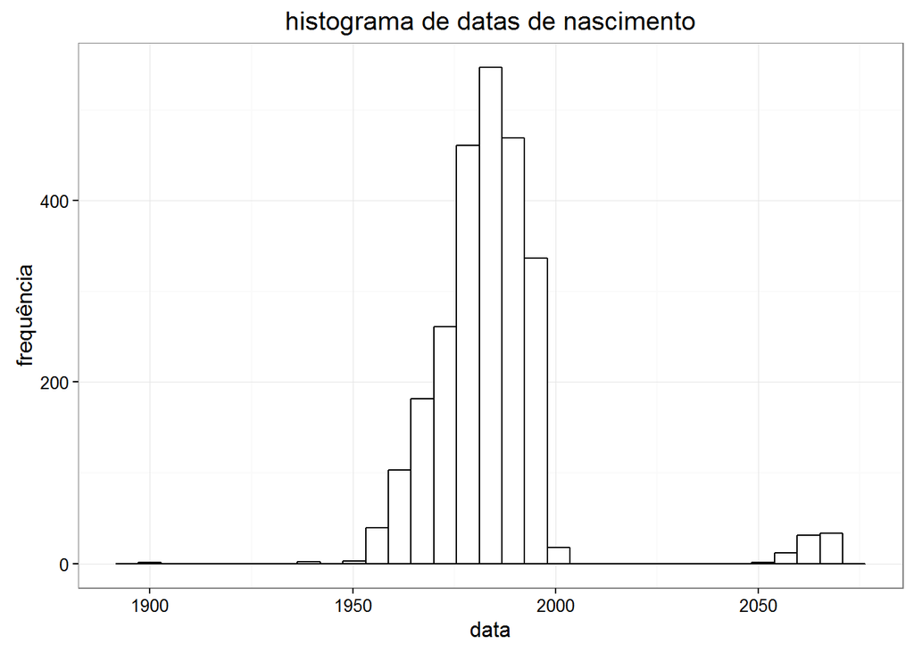

```r
ggplot() + aes(dados$data_nascimento) +
  geom_histogram(col="black", fill="white") +
  ggtitle("histograma de datas de nascimento") +
  xlab("data") +
  ylab("frequência")
```

```r
year(dados$data_nascimento) =
  year(dados$data_nascimento) -
  ifelse(year(dados$data_nascimento)>2000,
         100, 0)

summary(dados$data_nascimento)
```

```
##         Min.      1st Qu.       Median         Mean      3rd Qu.
## "1900-10-25" "1974-09-14" "1982-05-26" "1981-03-27" "1989-01-19"
##         Max.
## "2000-10-25"
```

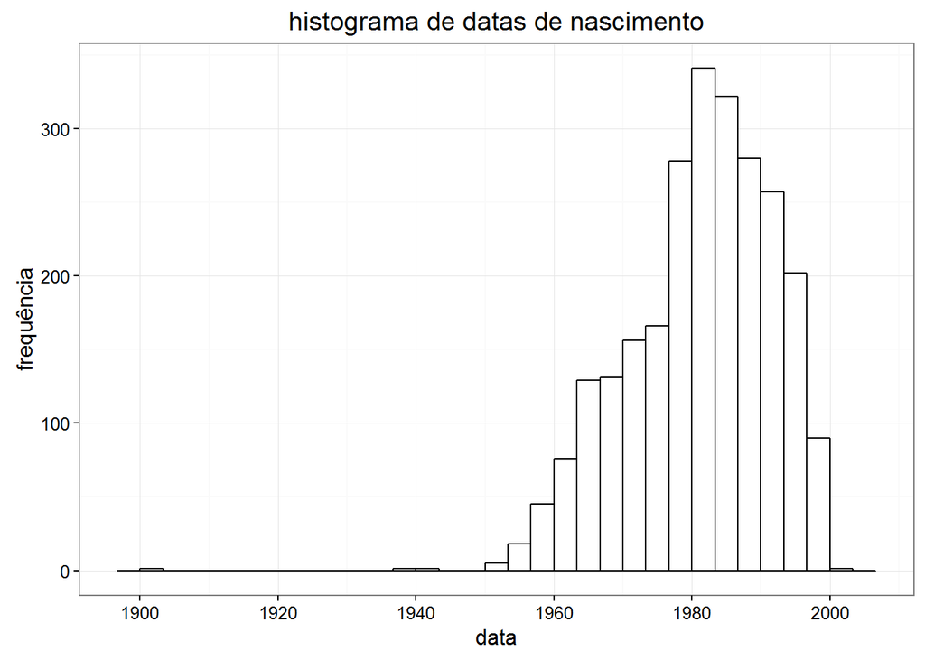

```r
ggplot() + aes(dados$data_nascimento) +
  geom_histogram(col="black", fill="white") +
  ggtitle("histograma de datas de nascimento") +
  xlab("data") +
  ylab("frequência")
```

O valor mínimo continua baixo. Quantos valores abaixo de 1930?

```r
sum(year(dados$data_nascimento)<1930)
```

```
## [1] 1
```

Salvar o índice do valor mínimo para posterior remoção (valor incorreto):

```r
indices_remover = which(year(dados$data_nascimento)<1930)
```

## Data de admissão

Procedimento semelhante ao usado para datas de nascimento.

```r
admis_1 = as.Date(dados$data_admissao, "%d/%m/%Y")
admis_2 = as.Date(dados$data_admissao, "%m/%d/%y")

dados$data_admissao = as.Date(admis_1)

dados$data_admissao[is.na(dados$data_admissao)] =
  as.Date(admis_2[is.na(dados$data_admissao)])

summary(dados$data_admissao)
```

```
##         Min.      1st Qu.       Median         Mean      3rd Qu.
## "1973-01-08" "2003-02-18" "2008-11-08" "2006-11-27" "2013-01-04"
##         Max.
## "2068-05-15"
```

```r
year(dados$data_admissao) =
  year(dados$data_admissao) -
  ifelse(year(dados$data_admissao)>=2068, 100, 0)

summary(dados$data_admissao)
```

```
##         Min.      1st Qu.       Median         Mean      3rd Qu.
## "1968-05-15" "2003-02-16" "2008-11-08" "2006-11-13" "2013-01-04"
##         Max.
## "2015-12-21"
```

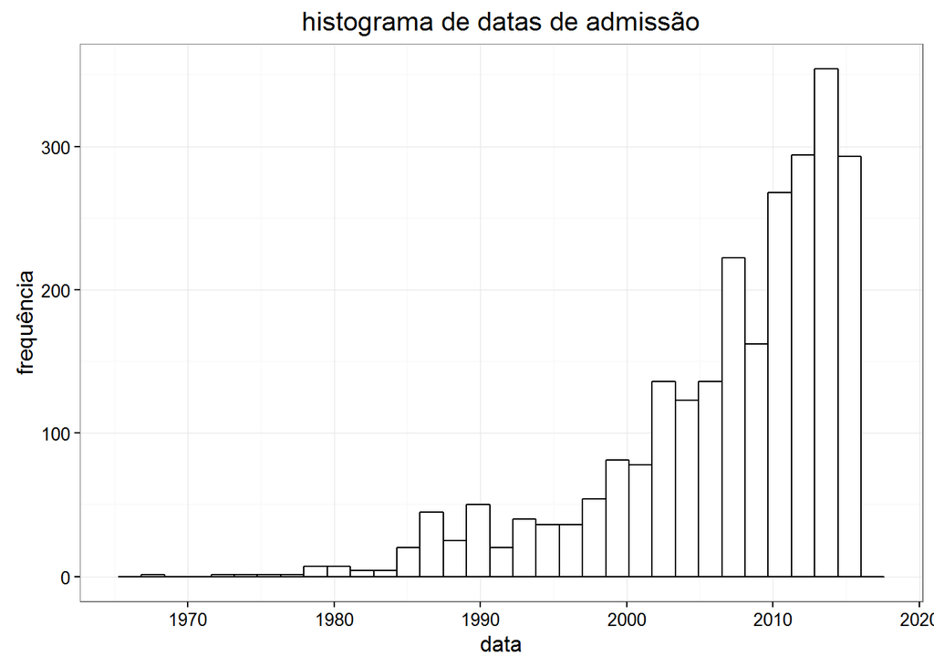

```r
ggplot() + aes(dados$data_admissao) +
  geom_histogram(col="black", fill="white") +
  ggtitle("histograma de datas de admissão") +
  xlab("data") +
  ylab("frequência")
```

Verificação de consistência entre datas de nascimento e de admissão:

```r
table(dados$area[(dados$data_nascimento+years(10))>dados$data_admissao])
```

```
##
## Administrativo       Aprendiz    Coordenação     Estagiário      Executivo
##             15              0              4              0              1
##       Gerência   Operacional         Trainee
##              1             30              0
```

Algumas datas de admissão são menos de 10 anos superiores à data de nascimento, o que certamente é um erro. Salvando índices para posterior remoção:

```r
remover_admissao = which((dados$data_nascimento + years(10)) >
                            dados$data_admissao)

indices_remover = c(indices_remover, remover_admissao)
```

## Salário mensal médio

Transformação de string para números:

```r
dados$salario = gsub("[^0-9,]", "", dados$salario)
dados$salario = gsub(",", ".", dados$salario)
dados$salario = as.numeric(dados$salario)

summary(dados$salario)
```

```
##     Min.  1st Qu.   Median     Mean  3rd Qu.     Max.
##    616.7   3248.0   4468.0   6542.0   6675.0 166800.0
```

## Avaliação de desempenho

Transformação em fator ordenado:

```r
head(dados$aval)
```

```
## [1] BOM   BOM   BOM   OTIMO OTIMO BOM
## Levels: BOM EXCELENTE INSATISFATORIO OTIMO
```

```r
dados$aval =
  factor(dados$aval,
         levels=c("INSATISFATORIO",
                  "BOM", "OTIMO",
                  "EXCELENTE"),
         ordered=TRUE)

head(dados$aval)
```

```
## [1] BOM   BOM   BOM   OTIMO OTIMO BOM
## Levels: INSATISFATORIO < BOM < OTIMO < EXCELENTE
```

## Remover dados

Remoção dos dados com datas de nascimento/admissão suspeitas.

```r
dados_removidos = dados[indices_remover,]
dados = dados[-indices_remover,]
```

# Exploração dos dados

## Desligamento

Quantidade absoluta e relativa de desligamentos:

```r
table(dados$desligamento)
```

```
##
##    0    1
## 2305  143
```

```r
table(dados$desligamento) / nrow(dados)
```

```
##
##          0          1
## 0.94158497 0.05841503
```

As classes são desbalanceadas - apenas cerca de 6% das pessoas na tabela se desligaram da empresa.

## ex-trainee

Quantidade de ex-trainees e relação com classe de desligamento:

```r
table(dados$ex_trainee)
```

```
##
##    0    1
## 2419   29
```

```r
table(dados$desligamento, dados$ex_trainee)
```

```
##
##        0    1
##   0 2278   27
##   1  141    2
```

```r
t(apply(table(dados$desligamento, dados$ex_trainee), 1,
        function (x) x/table(dados$ex_trainee)))
```

```
##
##              0          1
##   0 0.94171145 0.93103448
##   1 0.05828855 0.06896552
```

## Data de nascimento

Distribuição da variável por classe de desligamento:

```r
summary(dados$data_nascimento[dados$desligamento==0])
```

```
##         Min.      1st Qu.       Median         Mean      3rd Qu.
## "1939-04-03" "1974-07-14" "1982-04-24" "1981-02-14" "1989-01-19"
##         Max.
## "2000-10-25"
```

```r
summary(dados$data_nascimento[dados$desligamento==1])
```

```
##         Min.      1st Qu.       Median         Mean      3rd Qu.
## "1953-08-01" "1977-08-02" "1984-10-24" "1983-06-22" "1991-06-06"
##         Max.
## "1997-12-01"
```

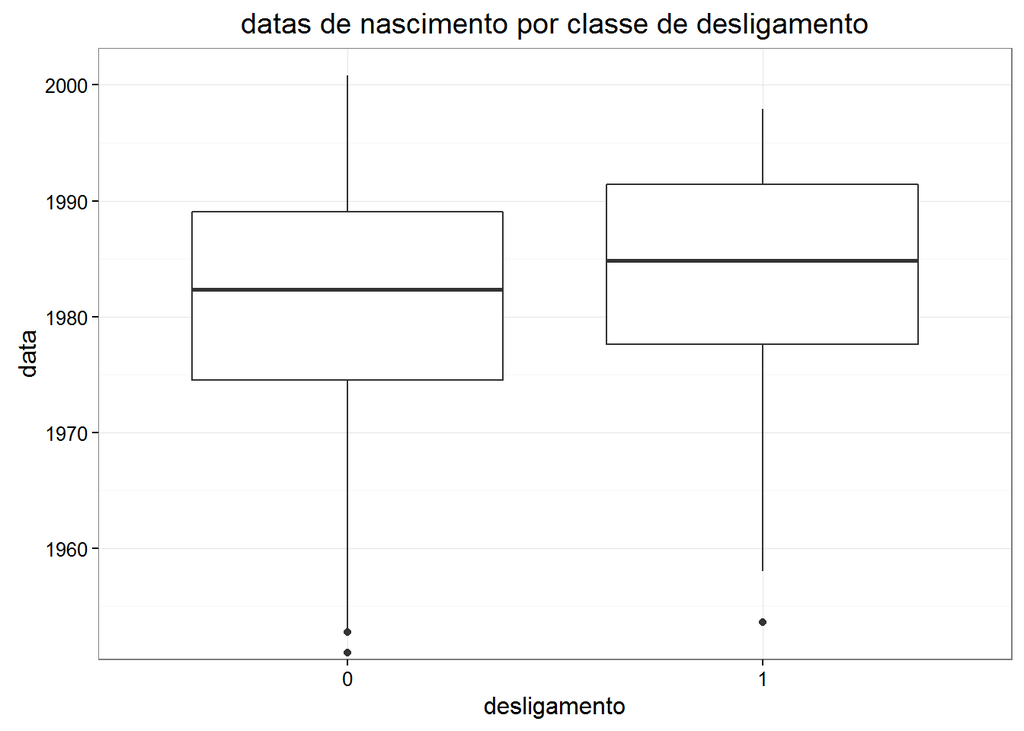

```r
ggplot(data = dados, aes(x = desligamento, y = data_nascimento)) +
  geom_boxplot() +
  ggtitle("datas de nascimento por classe de desligamento") +
  xlab("desligamento") +
  ylab("data")
```

Há uma leve tendência de pessoas mais novas a se desligarem mais, mas essa tendência pode ser um ruído nos dados disponíveis.

## Sexo

Quantidade de homens e mulheres e relação com classe de desligamento:

```r
table(dados$sexo)
```

```
##
##    F    M
##  277 2171
```

```r
table(dados$desligamento, dados$sexo)
```

```
##
##        F    M
##   0  256 2049
##   1   21  122
```

```r
t(apply(table(dados$desligamento, dados$sexo), 1, function (x) x/table(dados$sexo)))
```

```
##
##              F         M
##   0 0.92418773 0.9438047
##   1 0.07581227 0.0561953
```

Mulheres parecem mais propensas a se desligar, mas as classes são mais uma vez desbalanceadas, dificultanto sua utilização para previsão de resultados futuros.

## Data de admissão

Distribuição da variável por classe de desligamento:

```r
summary(dados$data_admissao[dados$desligamento==0])
```

```
##         Min.      1st Qu.       Median         Mean      3rd Qu.
## "1968-05-15" "2003-06-02" "2009-01-12" "2007-04-06" "2013-01-04"
##         Max.
## "2015-12-21"
```

```r
summary(dados$data_admissao[dados$desligamento==1])
```

```
##         Min.      1st Qu.       Median         Mean      3rd Qu.
## "1973-01-08" "2007-06-10" "2010-08-03" "2008-02-28" "2013-06-27"
##         Max.
## "2015-09-28"
```

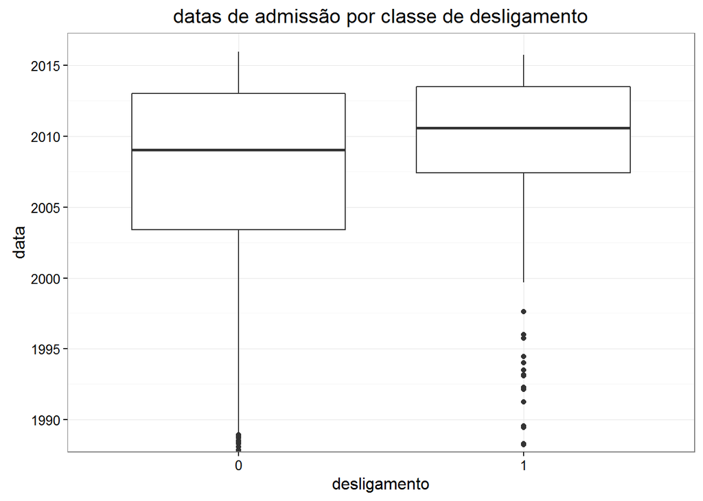

```r
ggplot(data = dados, aes(x = desligamento, y = data_admissao)) +
  geom_boxplot() +
  ggtitle("datas de admissão por classe de desligamento") +
  xlab("desligamento") +
  ylab("data")
```

A relação entre desligamento e uma data de admissão mais recente parece um pouco mais clara do que a relação entre desligamento e data de nascimento.

```r
table(dados$desligamento, dados$data_admissao<median(dados$data_admissao))
```

```
##
##     FALSE TRUE
##   0  1138 1167
##   1    86   57
```

```r
t(apply(table(dados$desligamento,
              dados$data_admissao<median(dados$data_admissao)),
        1,
        function (x) x /
          table(dados$data_admissao<median(dados$data_admissao))))
```

```
##
##          FALSE       TRUE
##   0 0.92973856 0.95343137
##   1 0.07026144 0.04656863
```

## Cargo

Há 867 categorias possíveis nessa variável, e a maior parte das categorias possui poucas observações:

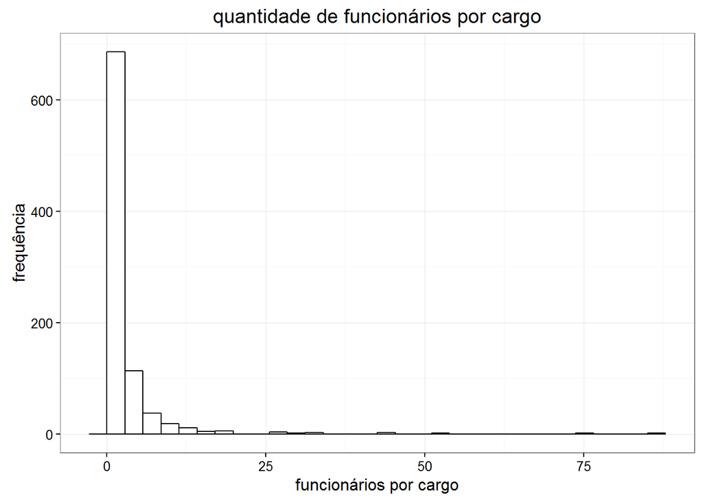

```r
ggplot() + aes(as.vector(table(dados$cargo))) +
  geom_histogram(col="black", fill="white") +
  ggtitle("quantidade de funcionários por cargo") +
  xlab("funcionários por cargo") +
  ylab("frequência")
```

Isso dificulta a análise - precisamos de 866 dummies para modelar essa variável, o que é muito dada a quantidade de observações disponíveis. Podemos ver se o número dos cargos quer dizer alguma coisa (ou seja, se a variável é de fato numérica e não categórica):

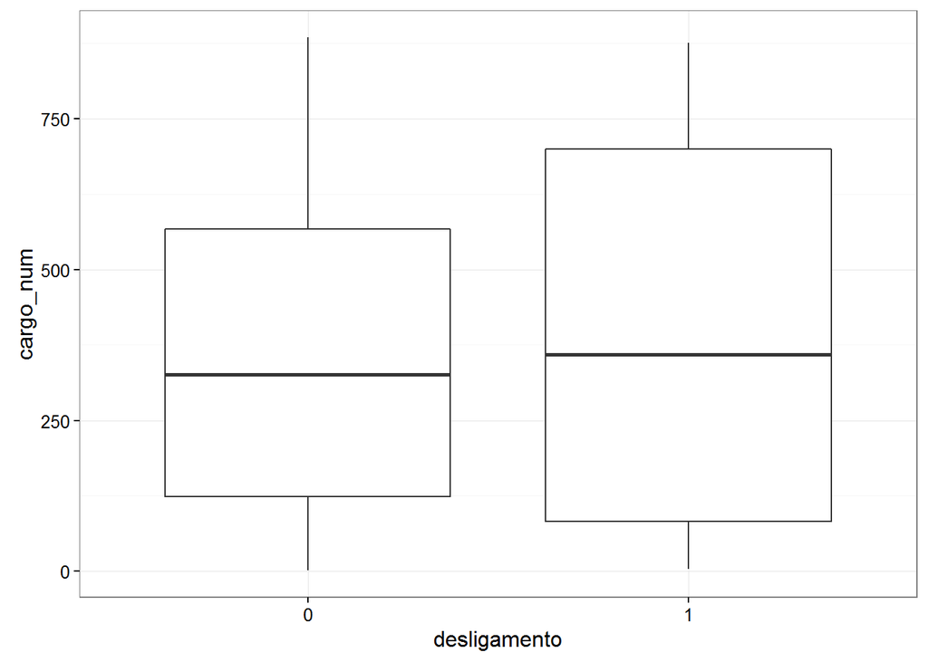

```r
dados$cargo_num = as.numeric(dados$cargo)
ggplot(data=dados) + aes(x=desligamento, y=cargo_num) + geom_boxplot()
```

```r
dados$cargo[dados$area=='Executivo']
```

```
## [1] 203 211 259 437 669 862
## 885 Levels: 1 10 100 101 102 103 104 105 106 107 108 109 11 110 111 ... 99
```

```r
dados$cargo[dados$area=='Estagiário']
```

```
##  [1] 839 842 844 848 848 852 848 848 848 848 848 844 848 848 848 848 844
## [18] 848 848 848 848 848 848 844 844 848 848 844 844 844 848 839 848 852
## [35] 844 852 852 852 848 844 848 848 848 844 839 839 844 844 844 848 881
## [52] 844 848 848 848 848 852 852 881 852 848 848 848 839
## 885 Levels: 1 10 100 101 102 103 104 105 106 107 108 109 11 110 111 ... 99
```

Não parece ser o caso, até porque funcionários em áreas distintas - executivos e estagiários - podem ter cargos com numeração semelhante.

Também podemos verificar se a distribuiução da quantidade de pessoas com o mesmo cargo é a mesma para quem se desligou ou não:

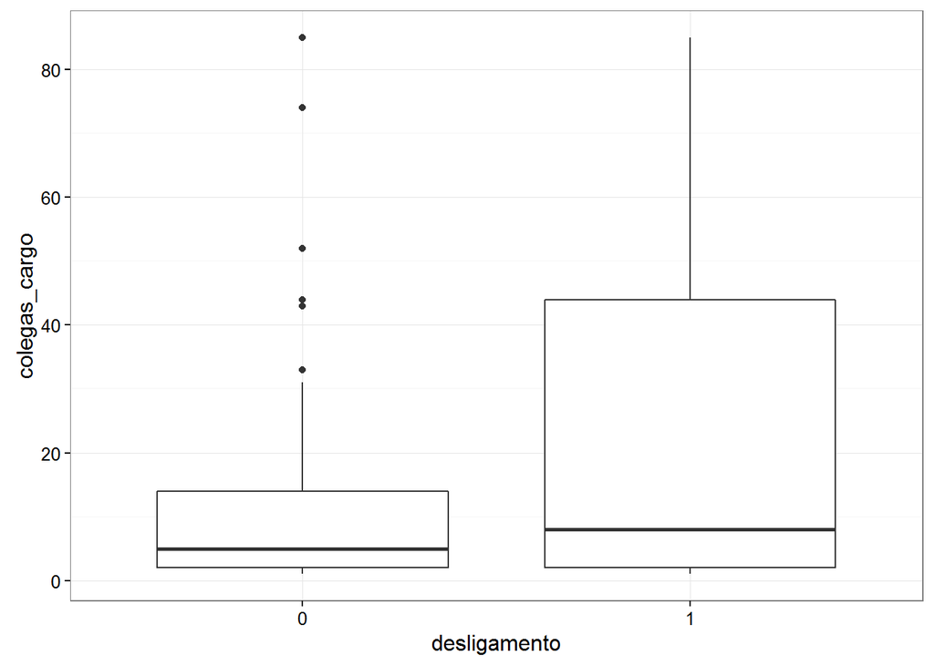

```r
# número de "colegas" por cargo
tabela_cargos = table(dados$cargo)
dados$colegas_cargo = tabela_cargos[dados$cargo]
ggplot(dados) + aes(x=desligamento, y=colegas_cargo) + geom_boxplot()
```

```r
sum(dados$colegas_cargo>40)
```

```
## [1] 298
```

```r
sum(dados$desligamento[dados$colegas_cargo>40]==1) /
  sum(dados$colegas_cargo>40)
```

```
## [1] 0.1610738
```

Parece haver uma tendência maior a se desligar em cargos mais “populosos”. Vou manter essa variável para análises posteriores.

## Área

As tabelas abaixo mostram a variação da taxa de desligamento por áreas.

```r
table(dados$desligamento, dados$area)
```

```
##
##     Administrativo Aprendiz Coordenação Estagiário Executivo Gerência
##   0            494       60          98         63         6       30
##   1             36       21           8          1         0        0
##
##     Operacional  Trainee
##   0         1546       8
##   1           77       0
```

```r
t(apply(table(dados$desligamento, dados$area),
              1, function (x) x/table(dados$area)))
```

```
##
##     Administrativo  Aprendiz Coordenação Estagiário Executivo Gerência
##   0     0.93207547 0.7407407   0.9245283   0.984375         1        1
##   1     0.06792453 0.2592593   0.0754717   0.015625         0        0
##
##     Operacional  Trainee
##   0   0.95255699       1
##   1   0.04744301       0
```

## Salário mensal médio

Distribuição da variável por classe de desligamento (gráfico limitado a máximo de R$ 50 mil para facilitar a visualização):

```r
summary(dados$salario[dados$desligamento=='0'])
```

```
##     Min.  1st Qu.   Median     Mean  3rd Qu.     Max.
##    616.7   3248.0   4427.0   6482.0   6620.0 166800.0
```

```r
summary(dados$salario[dados$desligamento=='1'])
```

```
##    Min. 1st Qu.  Median    Mean 3rd Qu.    Max.
##     630    2953    4245    6037    6892   47860
```

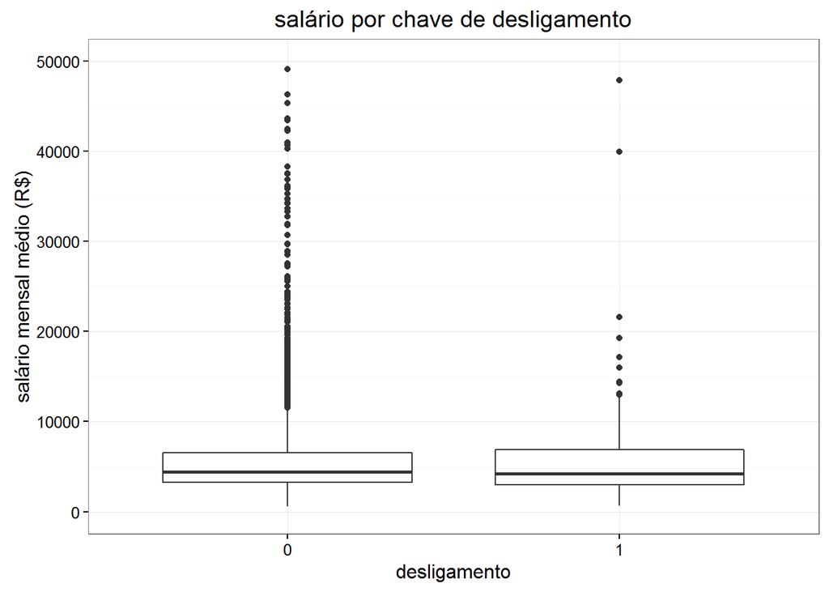

```r
ggplot(dados) + aes(x=desligamento, y=salario) +
  geom_boxplot() +
  ggtitle("salário por chave de desligamento") +
  xlab("desligamento") +
  ylab("salário mensal médio (R$)") +
  scale_y_continuous(limits=c(0, 50000))
```

A distribuição do salário parece não mudar muito. Mas há diferenças significativas de salário por área de atuação:

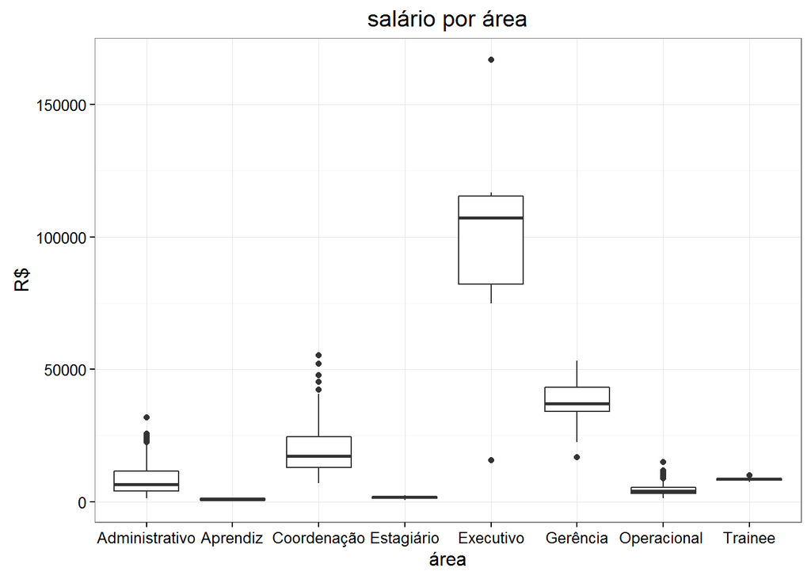

```r
ggplot(data = dados, aes(x = area, y = salario)) +
  geom_boxplot() +
  ggtitle("salário por área") +
  xlab("área") +
  ylab("R$")
```

Podemos ver se a distribuição de salário muda quando essas duas variáveis (desligamento e área) são consideradas:

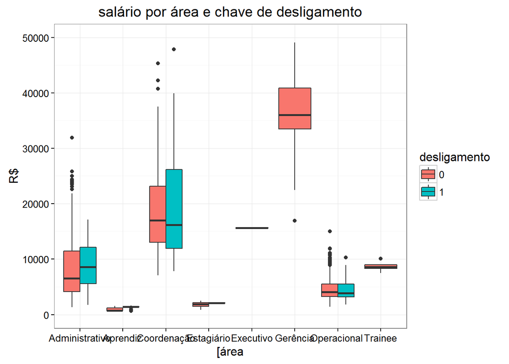

```r
ggplot(data = dados, aes(x = area, y = salario, fill=desligamento)) +
  geom_boxplot() + scale_y_continuous(limits=c(0, 50000)) +
  ggtitle("salário por área e chave de desligamento") +
  xlab("[área") +
  ylab("R$")
```

## Posição crítica

As tabelas abaixo mostram a relação entre desligamentos e ocupar ou não uma posição crítica na empresa:

```r
table(dados$pos_critica)
```

```
##
##    0    1
## 2191  257
```

```r
table(dados$desligamento, dados$pos_critica)
```

```
##
##        0    1
##   0 2066  239
##   1  125   18
```

```r
t(apply(table(dados$desligamento, dados$pos_critica),
              1, function (x) x / table(dados$pos_critica)))
```

```
##
##              0          1
##   0 0.94294843 0.92996109
##   1 0.05705157 0.07003891
```

Parece haver uma tendência maior para desligamento entre os que ocupam posições críticas.

## Gestor

Como no caso da variável cargo, trata-se de uma variável categórica com muitas categorias - 818. E aqui também o número de observações por categoria é pequeno, dificultando o uso da variável para previsões:

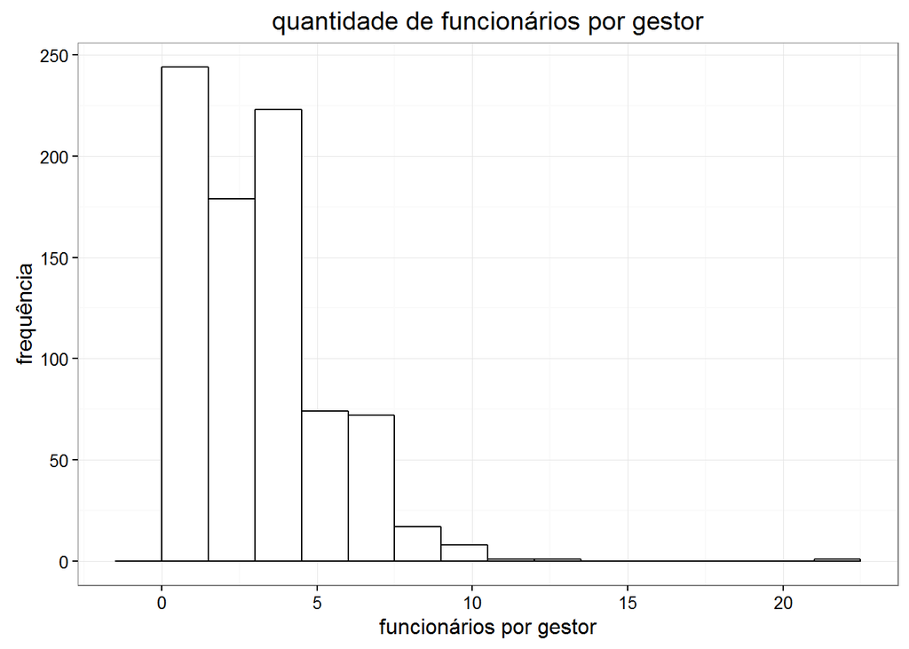

```r
tabela_gestores = table(dados$gestor)

ggplot() + aes(as.vector(tabela_gestores)) +
  geom_histogram(col="black", fill="white",
                 bins=length(unique(table(dados$gestor)))) +
  ggtitle("quantidade de funcionários por gestor") +
  xlab("funcionários por gestor") +
  ylab("frequência")
```

Novamente, os valores em si não parecem dizer muita coisa - ou seja, a variável é de fato categórica e não numérica.

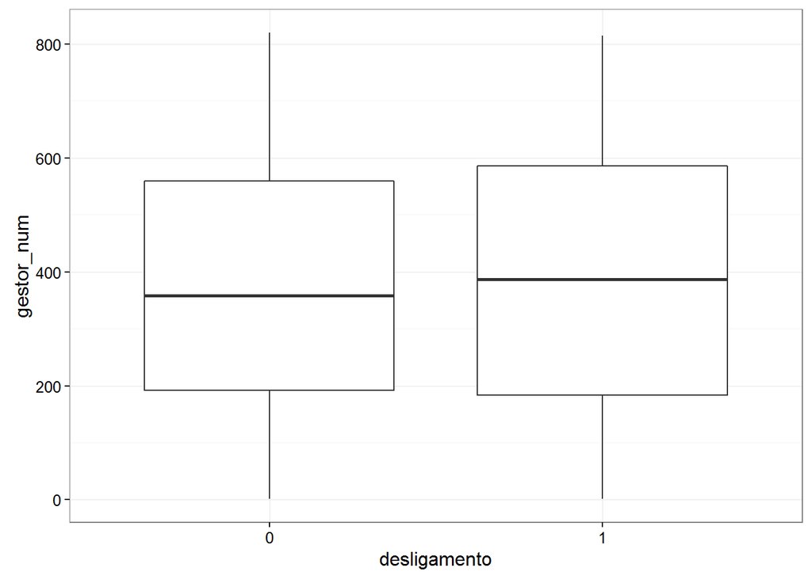

```r
dados$gestor_num = as.numeric(dados$gestor)
ggplot(data=dados) + aes(x=desligamento, y=gestor_num) + geom_boxplot()
```

```r
dados$gestor[dados$area=='Executivo']
```

```
## [1] 230 239 295 497 239 774
## 820 Levels: 1 10 100 101 102 103 104 105 106 107 108 109 11 110 111 ... 99
```

```r
dados$gestor[dados$area=='Estagiário']
```

```
##  [1] 191 766 197 177 650 29  781 615 537 782 783 785 588 87  332 197 787
## [18] 314 81  33  501 798 799 305 234 174 274 108 588 800 271 196 653 347
## [35] 804 358 385 407 376 207 807 306 694 296 207 207 814 576 490 375 504
## [52] 637 712 15  706 817 79  82  819 75  817 79  58  453
## 820 Levels: 1 10 100 101 102 103 104 105 106 107 108 109 11 110 111 ... 99
```

Aqui também podemos verificar se o número de observações na mesma categoria afeta o desligamento.

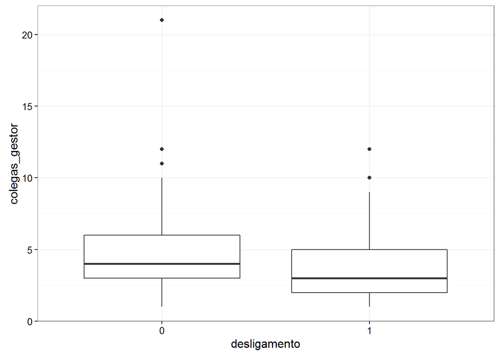

```r
dados$colegas_gestor = tabela_gestores[dados$gestor]
ggplot(dados) + aes(x=desligamento, y=colegas_gestor) + geom_boxplot()
```

Parece haver uma tendência a mais desligamento quando menos observações estão na mesma categoria.

## Avaliação

As tabelas abaixo mostram a relação entre desligamento e avaliação do funcionário.

```r
table(dados$desligamento, dados$aval)
```

```
##
##     INSATISFATORIO  BOM OTIMO EXCELENTE
##   0            104 1366   777        58
##   1              5   81    54         3
```

```r
table(dados$desligamento, dados$aval) /
  matrix(rep(table(dados$aval), 2), nrow=2, byrow=TRUE)
```

```
##
##     INSATISFATORIO        BOM      OTIMO  EXCELENTE
##   0     0.95412844 0.94402211 0.93501805 0.95081967
##   1     0.04587156 0.05597789 0.06498195 0.04918033
```

## Distância do trabalho

Distribuição da variável por classe de desligamento:

```r
summary(dados$dist[dados$desligamento=='0'])
```

```
##    Min. 1st Qu.  Median    Mean 3rd Qu.    Max.
##    0.00    8.00   16.00   15.98   24.00   32.00
```

```r
summary(dados$dist[dados$desligamento=='1'])
```

```
##    Min. 1st Qu.  Median    Mean 3rd Qu.    Max.
##    0.00    8.00   16.00   16.19   25.00   32.00
```

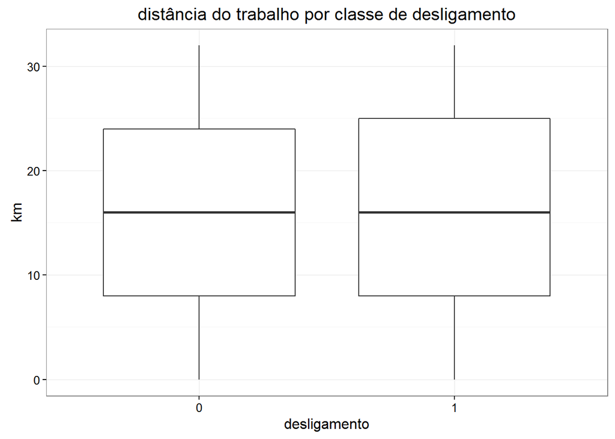

```r
ggplot(data = dados, aes(x = desligamento, y = dist)) +
  geom_boxplot() +
  ggtitle("distância do trabalho por classe de desligamento") +
  xlab("desligamento") +
  ylab("km")
```

Não parece haver diferença na distribuição da distância do trabalho entre categorias de desligamento.

## Tempo para chegar no trabalho

Distribuição da variável por classe de desligamento:

```r
summary(dados$tempo[dados$desligamento=='0'])
```

```
##    Min. 1st Qu.  Median    Mean 3rd Qu.    Max.
##    0.00    5.00   11.00   10.62   16.00   22.00
```

```r
summary(dados$tempo[dados$desligamento=='1'])
```

```
##    Min. 1st Qu.  Median    Mean 3rd Qu.    Max.
##    0.00    5.00   11.00   10.76   17.00   22.00
```

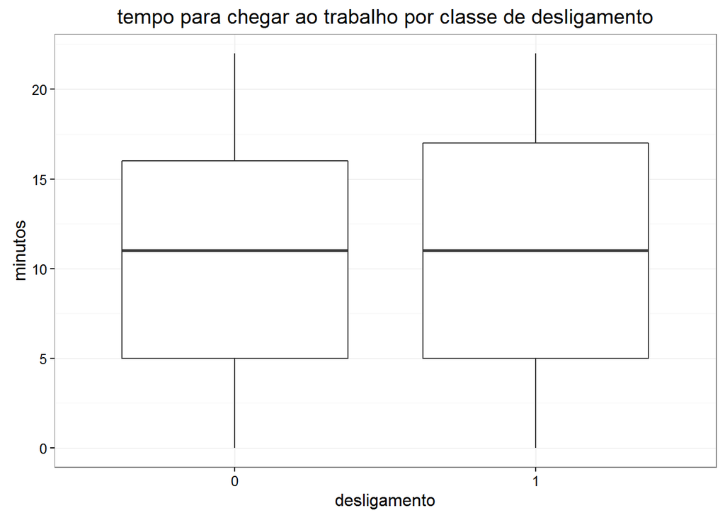

```r
ggplot(data = dados, aes(x = desligamento,
                         y = tempo)) +
  geom_boxplot() +
  ggtitle("tempo para chegar ao trabalho por classe de desligamento") +
  xlab("desligamento") +
  ylab("minutos")
```

Correlação com distância:

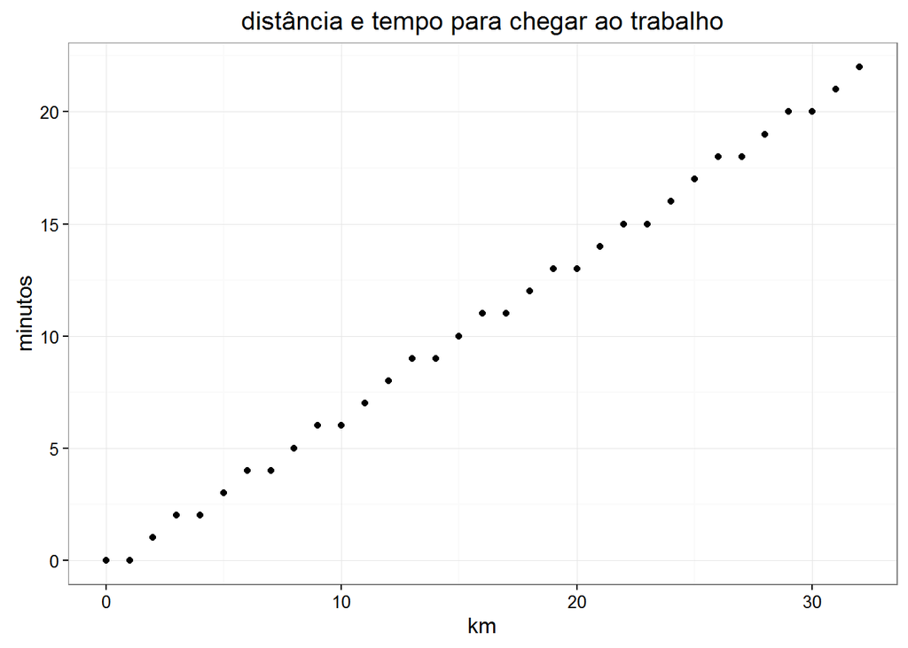

```r
qplot(dados$dist, dados$tempo) +
  ggtitle("distância e tempo para chegar ao trabalho") +
  xlab("km") +
  ylab("minutos")
```

O desempenho de alguns algoritmos pode ser prejudicado pela presença de variáveis com forte correlação. Mesmo quando isso não ocorre, duas variáveis tão fortemente correlacionadas são redundantes, porque a informação obtida é basicamente a mesma para as duas. Assim, vou remover uma dessas variáveis da tabela de variáveis para análise.

## Turnover mercado

Distribuição da variável por classe de desligamento:

```r
summary(dados$turnover[dados$desligamento=='0'])
```

```
##    Min. 1st Qu.  Median    Mean 3rd Qu.    Max.
##  0.0200  0.0800  0.1400  0.1428  0.2100  0.2600
```

```r
summary(dados$turnover[dados$desligamento=='1'])
```

```
##    Min. 1st Qu.  Median    Mean 3rd Qu.    Max.
##  0.0200  0.1000  0.1600  0.1552  0.2300  0.2600
```

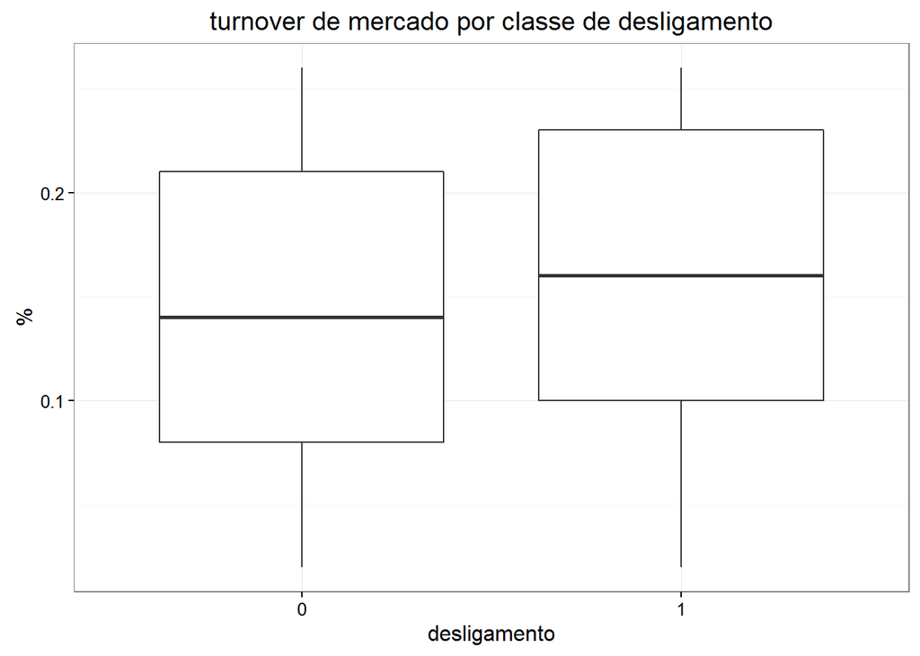

```r
ggplot(data = dados, aes(x = desligamento, y = turnover)) +
  geom_boxplot() +
  ggtitle("turnover de mercado por classe de desligamento") +
  xlab("desligamento") +
  ylab("%")
```

O desligamento parece associado a um *turnover* de mercado maior.

# Análise

## Mudar fatores

Alteração dos rótulos dos fatores para utilização posterior da função `train()`, que não aceita números como rótulos:

```r
levels(dados$desligamento) = c("nao", "sim")
```

## Remover variáveis

Remoção de variáveis julgadas desnecessárias:

- **cargo** e **gestor**: variáveis categóricas com grande número de categorias (dificuldade de avaliação) - substituídas pelo número de “colegas” na categoria
- **cargo_num** e **gestor_num**: tentativa (fracassada) de transformas as variáveis categóricas acima em variáveis numéricas
- **dist**: fortemente correlacionada com variável **tempo**.

```r
var_remover = c("cargo", "cargo_num", "gestor", "gestor_num",
                "dist")

dados_limpos = dados[,-which(names(dados) %in% var_remover)]
```

## Preparação dos dados

Criação de matriz com dados para treinamento de modelos:

```r
dados_limpos_X = model.matrix(desligamento~., dados_limpos)
dados_limpos_y = dados_limpos$desligamento
```

Partição entre dados de treino, validação e teste:

```r
indices_treino = createDataPartition(dados_limpos_y, p = 0.8,
                                     list=FALSE)

dados_treino_X = dados_limpos_X[indices_treino,]
dados_treino_y = dados_limpos_y[indices_treino]

dados_val_teste_X = dados_limpos_X[-as.vector(indices_treino),]
dados_val_teste_y = dados_limpos_y[-as.vector(indices_treino)]

indices_valida = createDataPartition(dados_val_teste_y, p=0.5,
                                     list=FALSE)

dados_valida_X = dados_val_teste_X[indices_valida,]
dados_valida_y = dados_val_teste_y[as.vector(indices_valida)]

dados_teste_X = dados_val_teste_X[-as.vector(indices_valida),]
dados_teste_y = dados_val_teste_y[-as.vector(indices_valida)]
```

Definição de folds para validação cruzada

```r
folds = createFolds(1:nrow(dados_treino_X), k=10, returnTrain = TRUE)
```

## Árvore de decisão com extreme gradient boosting

Definição do *cutoff* (probabilidade a partir da qual o modelo considera que haverá desligamento) por meio de análise da curva ROC das previsões feitas para os dados de validação:

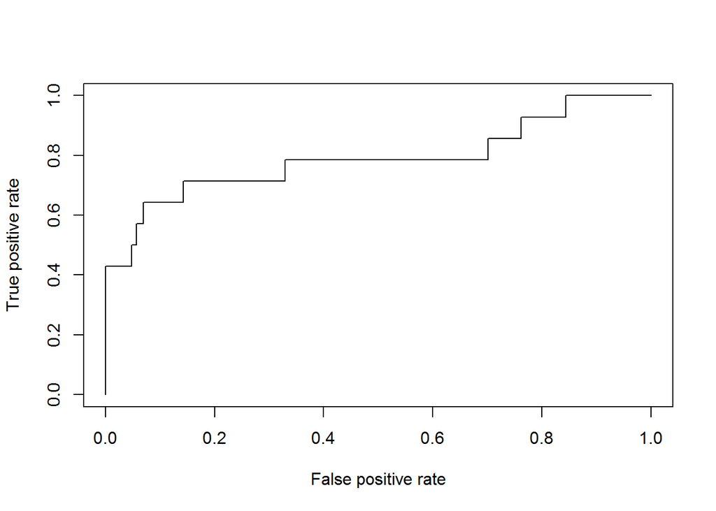

```r
# A previsão é para pertencer a desligamento=não:
# 1 - previsão é a chance de pertencer a desligamento=sim
xgb_valida_probs = 1 - predict(xgb_modelo, dados_valida_X)

xgb_valida_pred = prediction(xgb_valida_probs, dados_valida_y)

xgb_valida_roc = performance(xgb_valida_pred, "tpr", "fpr")
plot(xgb_valida_roc)
```

Pelo gráfico, podemos alcançar uma taxa de positivos verdadeiros de aproximadamente 80% com uma taxa de positivos falsos de aproximadamente 30%.

```r
indice_cutoff = min(which(round(xgb_valida_roc@y.values[[1]], 1)==0.8))

cutoff = xgb_valida_roc@alpha.values[[1]][indice_cutoff]
```

*Cutoff* escolhido: 1.88%

Taxa de positivos verdadeiros: 78.57%

Taxa de positivos falsos: 32.90%

## Análise final

```r
xgb_teste_probs = 1 - predict(xgb_modelo, dados_teste_X)

xgb_teste_prev = xgb_teste_probs > cutoff


table(xgb_teste_prev, dados_teste_y)
```

```
##               dados_teste_y
## xgb_teste_prev nao sim
##          FALSE 161   5
##          TRUE   69   9
```

# Conclusão

Algumas melhorias que podem ser feitas incluem:

- Exploração das variáveis categóricas excluídas (**cargo** e **gestor**)
- Análise da curva de aprendizado do modelo para verificar o trade-off entre viés e variância (ou seja, se precisamos de um modelo mais complexo para reduzir o viés ou de mais dados para reduzir a variância)
- Uso de outros algoritmos de classificação:
- Máquinas de vetores de suporte (*support vector machines*)
- Redes neurais
- Métodos lineares com penalização de parâmetros
- k-vizinhos mais próximos (*k-nearest neighbors*)